# Individual Assignment #3

### Regression with ARIMA Errors Laboratory.

#### (Total 40 pts.)

#### Due: Dec. 2 (before midnight)

As a newly minted MSBA you start working for a large resort hotel managing 1,877 rooms. A tour operator that you frequently do business with has requested a block of 60 rooms for Aug. 22. As this operator will pay a discounted rate for each room, your manager is uncertain if she should give this block of rooms to the tour operator, and she has asked you to provide model-based support for this decision.

Although the price is discounted and it may prevent you from selling some of these rooms at the regular price, if you reject this request, any empty rooms will not generate any revenue and you would have incurred an opportunity cost by not selling these rooms.

After judicious consideration of the economic tradeoffs in the Newsvendor model, you and your manager determine that the block should be assigned to the tour operator only if the probability of your organic demand (excluding the room block in question) is smaller than 67% (i.e., you are on track to achieve a 67% service level).

To address the booking question you examine the following data set and proceed to develop a demand forecast model.

The data set **Booking Exercise.csv** consists of daily observations of the following six variables:

- **DATE**: Calendar date corresponding to each observation.
- **DOW**: Index (1-7) to indicate the day of the week each **DATE** corresponds to. This is redundant and it is eliminated below.
- **DEMAND**: Number of rooms actually sold on each **DATE**.
- **TUESDAY.BOOK**: Number of rooms booked on the Tuesday of the previous week for each day of the forthcoming week. This variable is used as an input to inform the forecasts of **DEMAND** for each day of the forthcoming week.
- **PICKUP.RATIO**: This is a calculated variable obtained as **PICKUP.RATIO = DEMAND/TUESDAY.BOOK** historically as **DEMAND** is observed. Because of this is a calculated relationship you can use either **PICKUP.RATIO** or **TUESDAY.BOOK** but you cannot use both variables simultaneously in a model to predict **DEMAND**.
- **DOW.INDEX**: This is a pre-calculated indicator of day-of-the-week demand intensity. This is obtained by the Hotel using information beyond what it is contained in this data set.

The code below reads the data set which includes up to the latest demand information (August 17) and prepares the data for the modeling process:

```r
library(fpp3)
library(tseries)
X <- read.csv("Booking Exercise.csv") %>%
  select(DATE, DEMAND, TUESDAY.BOOK, DOW.INDEX) %>%
  mutate(DATE = ymd(DATE)) %>%
  as_tsibble(index = DATE)



Fcst.X <- X %>% filter(DATE >= ymd("2010-08-18"))
X <- X %>% filter(DATE <= ymd("2010-08-17"))
```

1. (15 pt.) Fit (a) an ETS, (b) a plain ARIMA, (c) a linear regression model to predict **DEMAND** as a function of **TUESDAY.BOOK**, (c) a non-seasonal regression model with ARIMA errors using **TUESDAY.BOOK** and **DOW.INDEX** as explanatory variables, and (d) a seasonal regression model with ARIMA errors using only **TUESDAY.BOOK** as an explanatory variable. You may use automatic model selection to fit an initial model, but especially in cases (c) and (d) you should modify the automatically fitted models when appropriate.

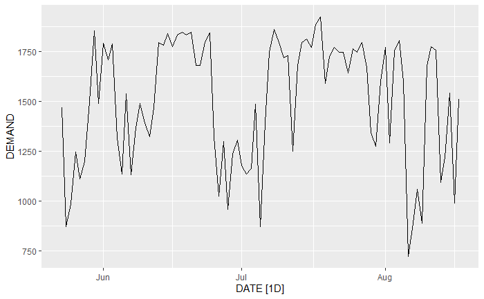

```r
X %>% autoplot(DEMAND)
```

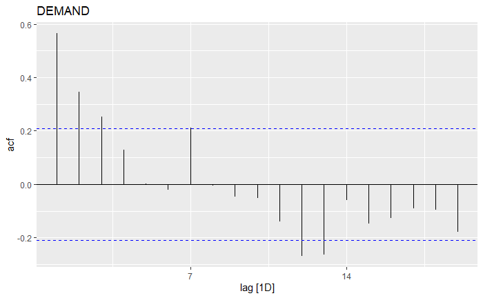

```r
X %>% ACF(DEMAND) %>%  autoplot() + labs(title = "DEMAND")
```

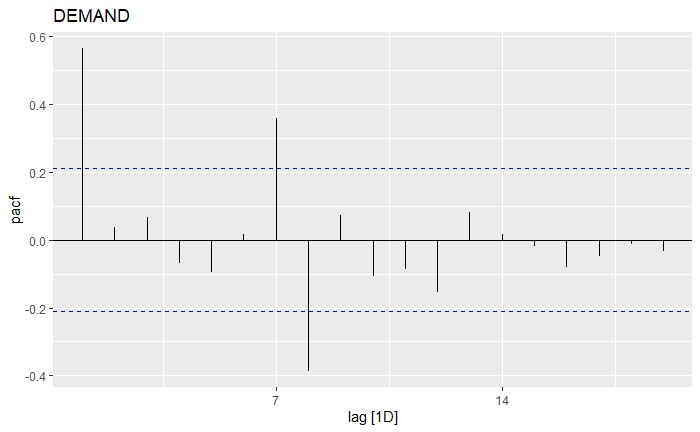

```r
X %>% PACF(DEMAND) %>%  autoplot() + labs(title = "DEMAND")
```

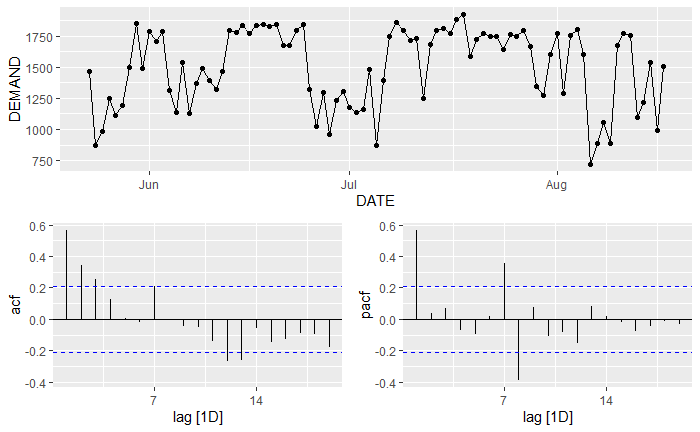

```r
X1 <- X %>%  mutate(diff.X = difference(DEMAND),diff2.X = difference(diff.X))

X1 %>% gg_tsdisplay(DEMAND, plot_type = "partial")
```

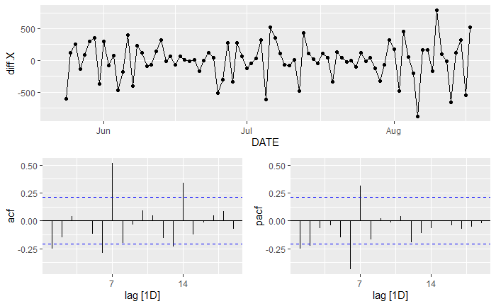

```r
X1 %>% gg_tsdisplay(diff.X, plot_type = "partial")
```

```r
X1 %>% features(DEMAND, unitroot_kpss)
```

| kpss_stat | kpss_pvalue |
| --- | --- |
| 0.1256031 | 0.1 |

```r
X1 %>% features(diff.X, unitroot_kpss)
```

| kpss_stat | kpss_pvalue |
| --- | --- |
| 0.02686275 | 0.1 |

```r
X1 %>% features(diff2.X, unitroot_kpss)
```

| kpss_stat | kpss_pvalue |
| --- | --- |
| 0.04828377 | 0.1 |

```r
X1 %>% features(DEMAND, unitroot_ndiffs)
```

| ndiffs |
| --- |
| 0 |

```r
X1 %>% features(DEMAND, unitroot_nsdiffs)
```

| nsdiffs |
| --- |
| 0 |

```r
X1$DEMAND %>% adf.test()
```

```
    Augmented Dickey-Fuller Test

data:  .
Dickey-Fuller = -3.6436, Lag order = 4, p-value = 0.03428
alternative hypothesis: stationary
```

```r
X1$diff.X %>%
  na.omit() %>%  # Removing the leading NA
  adf.test()
```

```
    Augmented Dickey-Fuller Test

data:  .
Dickey-Fuller = -5.4113, Lag order = 4, p-value = 0.01
alternative hypothesis: stationary
```

```r
X1$diff2.X %>%
  na.omit() %>%  # Removing the leading NA
  adf.test()
```

```
    Augmented Dickey-Fuller Test

data:  .
Dickey-Fuller = -5.4236, Lag order = 4, p-value = 0.01
alternative hypothesis: stationary
```

```r
# Data is stationary, no differencing required
```

```r
m <- X %>% model(m_ETS = ETS(DEMAND),
                 m_ARIMA1 = ARIMA(DEMAND),
                 m_lr = TSLM(DEMAND ~ TUESDAY.BOOK),
                 m_ARIMA2 = ARIMA(DEMAND ~ TUESDAY.BOOK +   DOW.INDEX + pdq(1,0,0)),
                 m_ARIMA3 = ARIMA(DEMAND ~ TUESDAY.BOOK +   pdq(1,1,3) + PDQ(1,1,0)))

m %>% select(m_ETS) %>% report()
```

```
Series: DEMAND
Model: ETS(A,N,A)
  Smoothing parameters:
    alpha = 0.9998969
    gamma = 0.0001000471

  Initial states:
     l[0]      s[0]     s[-1]    s[-2]    s[-3]    s[-4]     s[-5]    s[-6]
 1465.946 -95.33474 -132.6443 95.16317 147.1579 87.43041 -210.9891 109.2166

  sigma^2:  42400.13

     AIC     AICc      BIC
1326.011 1328.905 1350.670
```

```r
m %>% select(m_ARIMA1) %>% report()
```

```
Series: DEMAND
Model: ARIMA(1,0,0)(2,0,0)[7] w/ mean

Coefficients:
         ar1    sar1    sar2  constant
      0.7322  0.4746  0.2035   123.243
s.e.  0.0726  0.1086  0.1273    18.864

sigma^2 estimated as 47972:  log likelihood=-592.53
AIC=1195.07   AICc=1195.81   BIC=1207.4
```

```r
m %>% select(m_lr) %>% report()
```

```
Series: DEMAND
Model: TSLM

Residuals:
    Min      1Q  Median      3Q     Max
-296.95  -78.79   14.88   99.72  334.48

Coefficients:
              Estimate Std. Error t value Pr(>|t|)
(Intercept)  521.74996   48.84698   10.68   <2e-16 ***
TUESDAY.BOOK   0.69559    0.03323   20.93   <2e-16 ***
---
Signif. codes:  0 ‘***’ 0.001 ‘**’ 0.01 ‘*’ 0.05 ‘.’ 0.1 ‘ ’ 1

Residual standard error: 126.9 on 85 degrees of freedom
Multiple R-squared: 0.8375, Adjusted R-squared: 0.8356
F-statistic: 438.1 on 1 and 85 DF, p-value: < 2.22e-16
```

```r
m %>% select(m_ARIMA2) %>% report()
```

```
Series: DEMAND
Model: LM w/ ARIMA(1,0,0) errors

Coefficients:
         ar1  TUESDAY.BOOK  DOW.INDEX  intercept
      0.4948        0.8049   851.1024  -480.9254
s.e.  0.1032        0.0381   150.1665   180.4826

sigma^2 estimated as 9087:  log likelihood=-518.02
AIC=1046.05   AICc=1046.79   BIC=1058.38
```

```r
m %>% select(m_ARIMA3) %>% report()
```

```
Series: DEMAND
Model: LM w/ ARIMA(1,1,3)(1,1,0)[7] errors

Coefficients:
          ar1     ma1      ma2      ma3     sar1  TUESDAY.BOOK
      -0.7386  0.3962  -0.6865  -0.0828  -0.5673        0.6793
s.e.   0.1231  0.2178   0.1488   0.1806   0.0996        0.0317

sigma^2 estimated as 10235:  log likelihood=-475.93
AIC=965.87   AICc=967.44   BIC=982.45
```

2. (5 pt.) Which of the models are valid?

```r
m %>% augment() %>%
  features(.resid, ljung_box, lag = 10)
```

| .model | lb_stat | lb_pvalue |
| --- | --- | --- |
| m_ARIMA1 | 3.897186 | 9.518659e-01 |
| m_ARIMA2 | 13.492238 | 1.974367e-01 |
| m_ARIMA3 | 10.097931 | 4.319439e-01 |
| m_ETS | 9.038257 | 5.284767e-01 |
| m_lr | 58.732556 | 6.290528e-09 |

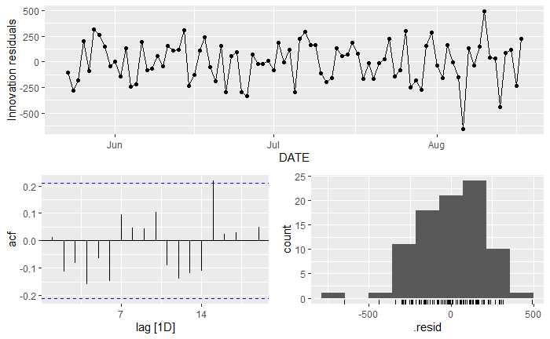

```r
m %>% select(m_ETS) %>% gg_tsresiduals()
```

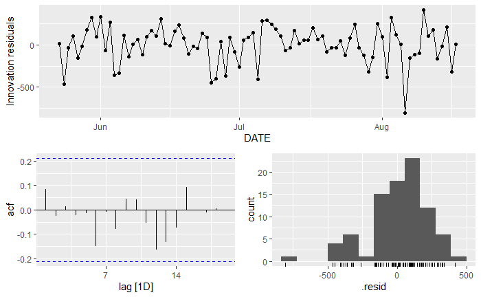

```r
m %>% select(m_ARIMA1) %>% gg_tsresiduals()
```

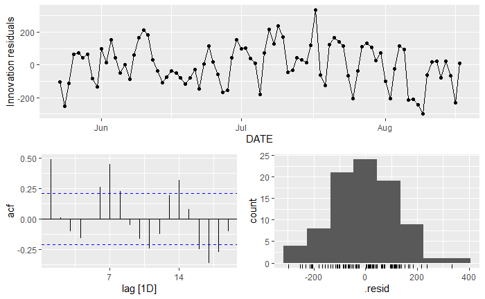

```r
m %>% select(m_lr) %>% gg_tsresiduals()
```

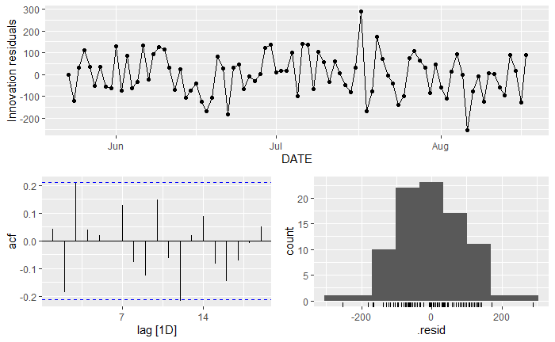

```r
m %>% select(m_ARIMA2) %>% gg_tsresiduals()
```

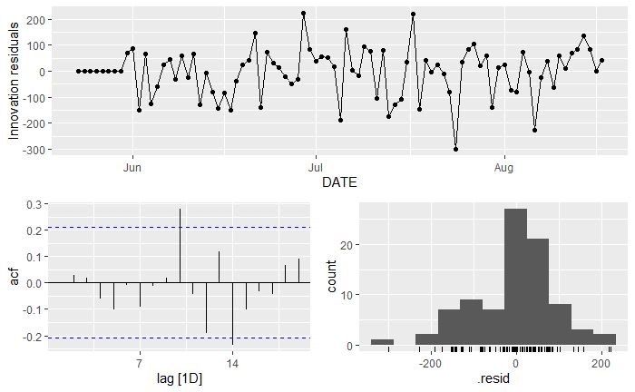

```r
m %>% select(m_ARIMA3) %>% gg_tsresiduals()
```

The Null Hypothesis of the Ljung-Box test is that residuals are uncorrelated. Hence, with a large p-value we can conclude that the residual independence cannot be rejected.

From the residual p-values, we can conclude that the ARIMA and ETS models have high p-value, but for the linear regression model we can conclude that the residuals are not independent. So there is a validity problem with the linear regression model.

```r
cor(X$DEMAND, X$TUESDAY.BOOK)
```

```
[1] 0.9151554
```

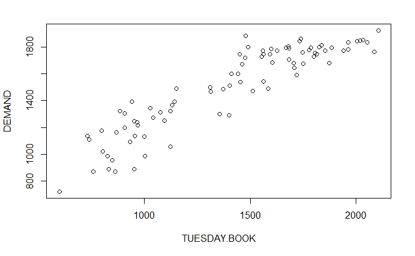

```r
plot(DEMAND ~ TUESDAY.BOOK, data = X)
```

```r
# TUESDAY.BOOK +    DOW.INDEX
```

3. (5 pt.) Using the information criteria (AICc and BIC) what is the best model?

```r
m %>% glance() %>%
  select(.model, AIC, AICc, BIC)
```

| .model | AIC | AICc | BIC |
| --- | --- | --- | --- |
| m_ETS | 1326.0105 | 1328.9053 | 1350.6696 |
| m_ARIMA1 | 1195.0662 | 1195.8070 | 1207.3958 |
| m_lr | 846.6954 | 846.9846 | 854.0931 |
| m_ARIMA2 | 1046.0499 | 1046.7906 | 1058.3794 |
| m_ARIMA3 | 965.8664 | 967.4439 | 982.4525 |

```r
NA
```

After looking at the correlation value, LJung Box data and the IC, we can select the seasonal regression model with ARIMA errors model.

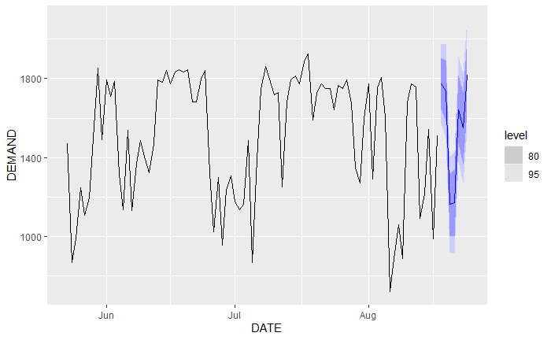

```r
new_book_data <- new_data(X,7) %>%
  mutate(TUESDAY.BOOK = c(1657,1643,1124,1074,1839,1862,1886))

Forecast <- m %>% select(m_ARIMA3) %>%
  forecast(new_data = new_book_data)

Forecast %>% autoplot() + geom_line(X, mapping = aes(y = DEMAND))
```

5. (10 pt.) What is your recommendation for your manager regarding the tour operator block? Should your manager sell the block of 60 rooms at a discounted price? Justify your answer.

```r
1877*0.67
```

```
[1] 1257.59
```

```r
# Date       Demand         Mean     Tuesday.book
# 2010-08-18 N(1767, 10394) 1766.970 1657

# 2010-08-19 N(1739, 12987) 1739.352 1643

# 2010-08-20 N(1184, 13633) 1184.003 1124

# 2010-08-21 N(1198, 13795) 1197.887 1074

# 2010-08-22 N(1655, 13835) 1654.776 1839

# 2010-08-23 N(1563, 13845) 1562.742 1862

# 2010-08-24 N(1809, 13847) 1809.009 1886
```